# Techniques d'apprentissage automatique

## TP2 - Apprentissage supervisé avec python

### Alexis Pister

```python
# Imports
import numpy as np
np.set_printoptions(threshold=np.nan,suppress=True)
import pandas as pd
import warnings
import matplotlib.pyplot as plt
import sklearn
warnings.filterwarnings('ignore')
```

### Question 1

```
(4375,)
```

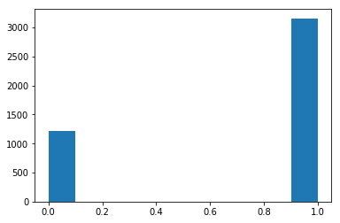

```python
# Data processing
df = pd.read_csv('./credit_scoring.csv', sep=";")
data = df.values
colonnes = df.columns

# Variables caracteristiques
X = data[:,:-1]
# Labels a predire
Y = data[:,-1]

# Analyse des données
print(np.shape(Y))
plt.hist(Y)
```

Le jeu de données comporte 4375 échantillons, avec 1216 négatifs (0) et 3159 positifs (1).

### Question 2

```python
from sklearn.model_selection import train_test_split
from sklearn.tree import DecisionTreeClassifier
from sklearn.metrics import classification_report, confusion_matrix, accuracy_score

# Separation en train et test set
X_train, X_test, y_train, y_test = train_test_split(X, Y, test_size=0.33, random_state=42)

# Arbre CART
# Classifier initialisation
classifier = DecisionTreeClassifier(random_state=1)
# training
classifier.fit(X_train, y_train)

# Test
y_pred = classifier.predict(X_test)

# Results of classification (metrics)
print(confusion_matrix(y_test, y_pred))
print(classification_report(y_test, y_pred))
```

```
[[183 214]
 [201 846]]
              precision    recall  f1-score   support

         0.0       0.48      0.46      0.47       397
         1.0       0.80      0.81      0.80      1047

   micro avg       0.71      0.71      0.71      1444
   macro avg       0.64      0.63      0.64      1444
weighted avg       0.71      0.71      0.71      1444
```

```python
from sklearn.neighbors import KNeighborsClassifier
# K plus proches voisins

# Classifier initialisation
kppv = KNeighborsClassifier(n_neighbors=5)
# training
kppv.fit(X_train, y_train)

# Test
y_pred = kppv.predict(X_test)

# Results of classification (metrics)
print(confusion_matrix(y_test, y_pred))
print(classification_report(y_test, y_pred))
```

```
[[124 273]
 [131 916]]
              precision    recall  f1-score   support

         0.0       0.49      0.31      0.38       397
         1.0       0.77      0.87      0.82      1047

   micro avg       0.72      0.72      0.72      1444
   macro avg       0.63      0.59      0.60      1444
weighted avg       0.69      0.72      0.70      1444
```

Dans notre cas d'étude où on recherche des profils qui peuvent rembourser des crédit, il parait plus judicieux de comparer la précision que le rappel. En effet, si la banque donne un crédit non rembousé, elle est beaucoup plus perdante que si elle gagne un crédit en plus. On cherche donc plus la sécurité et donc la précision que la quantité associée au rappel.

L'arbre CART et les k-plus-proche-voisins donnent respectivement un score-F1 (correspondant ici à l'accuracy) pondéré par les proportions des 2 classes de 0.71 et 0.70, et une précision pondérée de 0.71 et 0.69.

Les 2 classifieurs donnent donc des résultats très proche et il est dur de les différencier. A choisir, on favoriserai tout de même l'arbre CART donnant un score et une précision un peu plus important.

### Question 3

```python
# On normalise les données
from sklearn.preprocessing import StandardScaler, MinMaxScaler

# Standard normalisation
print('Standard normalisation')
Xnorm = StandardScaler().fit(X).transform(X)

# Separation en train et test set
X_train, X_test, y_train, y_test = train_test_split(Xnorm, Y, test_size=0.33, random_state=42)

# Arbre CART
print('Arbre CART')
classifier.fit(X_train, y_train)
y_pred = classifier.predict(X_test)
print(confusion_matrix(y_test, y_pred))
print(classification_report(y_test, y_pred))

# kppv
print('KPPV')
kppv.fit(X_train, y_train)
y_pred = kppv.predict(X_test)
print(confusion_matrix(y_test, y_pred))
print(classification_report(y_test, y_pred))
```

```
Standard normalisation
Arbre CART
[[184 213]
 [202 845]]
              precision    recall  f1-score   support

         0.0       0.48      0.46      0.47       397
         1.0       0.80      0.81      0.80      1047

   micro avg       0.71      0.71      0.71      1444
   macro avg       0.64      0.64      0.64      1444
weighted avg       0.71      0.71      0.71      1444

KPPV
[[179 218]
 [147 900]]
              precision    recall  f1-score   support

         0.0       0.55      0.45      0.50       397
         1.0       0.81      0.86      0.83      1047

   micro avg       0.75      0.75      0.75      1444
   macro avg       0.68      0.66      0.66      1444
weighted avg       0.73      0.75      0.74      1444
```

```python
# MinMax normalisation
print('MinMax normalisation')
Xnorm = MinMaxScaler().fit(X).transform(X)

# Separation en train et test set
X_train, X_test, y_train, y_test = train_test_split(Xnorm, Y, test_size=0.33, random_state=42)

# Arbre CART
print('Arbre CART')
classifier.fit(X_train, y_train)
y_pred = classifier.predict(X_test)
print(confusion_matrix(y_test, y_pred))
print(classification_report(y_test, y_pred))

# kpv
print('KPPV')
kppv.fit(X_train, y_train)
y_pred = kppv.predict(X_test)
print(confusion_matrix(y_test, y_pred))
print(classification_report(y_test, y_pred))
```

```
MinMax normalisation
Arbre CART
[[183 214]
 [202 845]]
              precision    recall  f1-score   support

         0.0       0.48      0.46      0.47       397
         1.0       0.80      0.81      0.80      1047

   micro avg       0.71      0.71      0.71      1444
   macro avg       0.64      0.63      0.64      1444
weighted avg       0.71      0.71      0.71      1444

KPPV
[[170 227]
 [139 908]]
              precision    recall  f1-score   support

         0.0       0.55      0.43      0.48       397
         1.0       0.80      0.87      0.83      1047

   micro avg       0.75      0.75      0.75      1444
   macro avg       0.68      0.65      0.66      1444
weighted avg       0.73      0.75      0.74      1444
```

Pour le classifieur CART, il semble que normaliser les données ne change pas les metriques de classification, autant pour une normalisation normale que Min-Max. Cependant, cela améliore la classification pour la technique des k-plus-proche-voisins. La précision et le score f1 pondérés passent respectivement de 0.69 et 0.70 à 0.73 et 0.74 après la normalisation (autant pour la normalisation normale et MinMax), ce qui donne une classification meilleurs que l'arbre de décision.

### Question 4 : Ajout de l'ACP

```python
from sklearn.decomposition import PCA

# PCA
acp = PCA(svd_solver='full')
Xacp = acp.fit_transform(Xnorm)

# On va garder les 4 premieres dimensions de l'acp qui expliquent 90% de l'information
print("Variance expliquée par les composantes de l'acp : ", acp.explained_variance_ratio_)

# On rajoute les 4 nouvelles dimensions au jeu de données
Xnew = np.hstack((Xnorm, Xacp[:,:4]))

# Separation en train et test set
X_train_pca, X_test_pca, y_train, y_test = train_test_split(Xnew, Y, test_size=0.33, random_state=42)

# Arbre CART
print('Arbre CART')
classifier.fit(X_train_pca, y_train)
y_pred = classifier.predict(X_test_pca)
print(confusion_matrix(y_test, y_pred))
print(classification_report(y_test, y_pred))

# kpv
print('KPPV')
kppv.fit(X_train_pca, y_train)
y_pred = kppv.predict(X_test_pca)
print(confusion_matrix(y_test, y_pred))
print(classification_report(y_test, y_pred))
```

```
Variance expliquée par les composantes de l'acp :  [0.3132101  0.23599    0.16118877 0.13889973 0.05277771 0.04561142
 0.01634432 0.01459562 0.01082235 0.0064157  0.00173251 0.00129816
 0.00111361]
Arbre CART
[[204 193]
 [209 838]]
              precision    recall  f1-score   support

         0.0       0.49      0.51      0.50       397
         1.0       0.81      0.80      0.81      1047

   micro avg       0.72      0.72      0.72      1444
   macro avg       0.65      0.66      0.66      1444
weighted avg       0.73      0.72      0.72      1444

KPPV
[[171 226]
 [140 907]]
              precision    recall  f1-score   support

         0.0       0.55      0.43      0.48       397
         1.0       0.80      0.87      0.83      1047

   micro avg       0.75      0.75      0.75      1444
   macro avg       0.68      0.65      0.66      1444
weighted avg       0.73      0.75      0.74      1444
```

On remarque que l'ajout des 4 dimensions de l'ACP augmente la précision, le rappel et le score pondérés de 1% pour l'arbre de décision. On peut considérer que dans un sens l'ACP rajoute une part d'informations au données qui amélore la classification, même si elle se base sur les variables initiales.

### Question 5

```
['Income' 'Price' 'Seniority' 'Amount' 'Age' 'Assets' 'Expenses' 'Records'
 'Time' 'Job' 'Debt' 'Home' 'Marital']
```

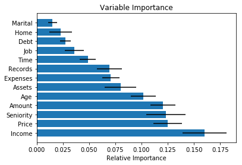

```python
from sklearn.ensemble import RandomForestClassifier
colonnes = np.array(colonnes)
clf = RandomForestClassifier(n_estimators=100)
clf.fit(Xnorm, Y)
importances=clf.feature_importances_
std = np.std([tree.feature_importances_ for tree in clf.estimators_],axis=0)
sorted_idx = np.argsort(importances)[::-1]
features = colonnes
print(features[sorted_idx])
padding = np.arange(X_train.size/len(X_train)) + 0.5
plt.barh(padding, importances[sorted_idx],xerr=std[sorted_idx], align='center')
plt.yticks(padding, features[sorted_idx])
plt.xlabel("Relative Importance")
plt.title("Variable Importance")
plt.show()
```

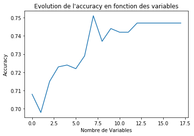

```python
# On determine le nombre de variables a garder
KNN=KNeighborsClassifier(n_neighbors=5)
scores=np.zeros(X_train_pca.shape[1]+1)
for f in np.arange(0, X_train_pca.shape[1]+1):
    X1_f = X_train_pca[:,sorted_idx[:f+1]]
    X2_f = X_test_pca[:,sorted_idx[:f+1]]
    KNN.fit(X1_f,y_train)
    YKNN=KNN.predict(X2_f)
    scores[f]=np.round(accuracy_score(y_test,YKNN),3)
plt.plot(scores)
plt.xlabel("Nombre de Variables")
plt.ylabel("Accuracy")
plt.title("Evolution de l'accuracy en fonction des variables")
plt.show()
```

On peut voir à l'aide du graphique qu'on obtient une accuracy la plus grande de 0.75 en choisissant 7 variables.

### Question 6

```python
from sklearn.model_selection import GridSearchCV
# On va faire une recherche des meilleurs parametres pour l'arbre de decision et les KPPV

parameters = {'criterion': ['gini', 'entropy'], 'splitter': ['best', 'random'], 'max_depth':[None,2,3,4,5,6,7]}
tree = DecisionTreeClassifier(random_state=1)
clf = GridSearchCV(tree, parameters)
clf.fit(X_train_pca, y_train)
y_pred = clf.predict(X_test_pca)

print(clf.best_params_)
print(clf.best_score_)
```

```
{'splitter': 'random', 'criterion': 'entropy', 'max_depth': 5}
0.7703855339474582
```

Sur les paramètres étudiées (criterion, splitter et max_depth), le meilleurs classifieur est obtenu avec la fonction d'entropy comme fonction de qualité, une stratégie aléatoire pour choisir la séparation à chaque noeud, et une longueur maximal de l'arbre de 5. Un score de 0.77 est alors obtenu.

```python
parameters = {'n_neighbors':[3,4,5,6,7,8,9,10],
              'weights':['uniform', 'distance'],
              'algorithm':['auto', 'ball_tree', 'kd_tree', 'brute'],
              'p':[1,2]}
kppv = KNeighborsClassifier()
clf = GridSearchCV(kppv, parameters)
clf.fit(X_train_pca, y_train)
y_pred = clf.predict(X_test_pca)

print(clf.best_params_)
print(clf.best_score_)
```

```
{'n_neighbors': 7, 'weights': 'distance', 'algorithm': 'auto', 'p': 2}
0.7683384510406005
```

Pour les k-plus-proche-voisins, le meilleurs score de 0.76 est obtenu avec k = 7, la distance euclidienne utilisée, des poids inverses, et un algorithme de calcul des plus proches voisins décidé automatiquement.

### Question 7 : Pipeline

```python
from sklearn.pipeline import Pipeline, FeatureUnion

pipeline = Pipeline([
    ('Normalization', MinMaxScaler()),
    ('feats', FeatureUnion([
        ('PCA', PCA(n_components = 0.90, svd_solver='full'))
    ])),
    ('classifier', DecisionTreeClassifier(random_state=1))  # classifier
])

X_train, X_test, y_train, y_test = train_test_split(X, Y, test_size=0.33, random_state=42)

# train the classifier
fit = pipeline.fit(X_train, y_train)
# test the classifier
y_pred = pipeline.predict(X_test)

print(classification_report(y_test, y_pred))
```

```
              precision    recall  f1-score   support

         0.0       0.44      0.46      0.45       397
         1.0       0.79      0.78      0.78      1047

   micro avg       0.69      0.69      0.69      1444
   macro avg       0.62      0.62      0.62      1444
weighted avg       0.70      0.69      0.69      1444
```

```python
# KPPV
pipeline = Pipeline([
    ('Normalization', MinMaxScaler()),
    ('feats', FeatureUnion([
        ('PCA', PCA(n_components = 0.90, svd_solver='full'))
    ])),
    ('kppv', KNeighborsClassifier(n_neighbors=7))
])

# train the classifier
fit = pipeline.fit(X_train, y_train)
# test the classifier
y_pred = pipeline.predict(X_test)

print(classification_report(y_test, y_pred))
```

```
              precision    recall  f1-score   support

         0.0       0.54      0.41      0.47       397
         1.0       0.80      0.87      0.83      1047

   micro avg       0.74      0.74      0.74      1444
   macro avg       0.67      0.64      0.65      1444
weighted avg       0.73      0.74      0.73      1444
```

Les résultats ne sont pas exactement les mêmes. Cela doit venir de la normalisation qui se fait ici sur les jeux d'entrainement et les jeux de test de manère séparé.

### Question 8 : comparaison de classifieurs

```python
from sklearn.model_selection import KFold
from sklearn.model_selection import cross_val_score
from sklearn.naive_bayes import GaussianNB
from sklearn.neural_network import MLPClassifier
from sklearn.ensemble import BaggingClassifier
from sklearn.ensemble import AdaBoostClassifier
import time

# Differents classifieurs
clfs = {
'NB': GaussianNB(),
'CART': DecisionTreeClassifier(random_state=1),
'RF': RandomForestClassifier(n_estimators=50, random_state=1),
'ID3': DecisionTreeClassifier(criterion = 'entropy', random_state=1),
'MLP': MLPClassifier(solver='lbfgs',alpha=1e-5,hidden_layer_sizes=(20,10),random_state=1),
'KPPV': KNeighborsClassifier(n_neighbors=7),
'BAGGING': BaggingClassifier(n_estimators=50,random_state=1),
'ADABOOST': AdaBoostClassifier(n_estimators=50, random_state=1)
}

# Fonction de test des différents classifieurs
def run_classifiers(clfs,X,Y):
    Xnorm = MinMaxScaler().fit(X).transform(X)
    acp = PCA(n_components=0.90, svd_solver='full')
    Xacp = acp.fit_transform(Xnorm)
    Xproc = np.hstack((Xnorm, Xacp[:,:]))

    kf = KFold(n_splits=10, shuffle=True, random_state=1)
    for i in clfs:
        clf = clfs[i]
        print("\n\n======= {0} =======".format(i))
        start_time = time.time()
        cv_acc = cross_val_score(clf, Xproc, Y, cv=kf)
        print('\nTemps d\'exécution d\'un cross val : %s secondes'%(time.time() - start_time))
        cv_auc = cross_val_score(clf, Xproc, Y, cv=kf, scoring='roc_auc')
        cv_prec = cross_val_score(clf, Xproc, Y, cv=kf, scoring='precision')
        print("Accuracy for {0} is: {1:.3f} +/- {2:.3f}".format(i, np.mean(cv_acc), np.std(cv_acc)))
        print("AUC for {0} is: {1:.3f} +/- {2:.3f}".format(i, cv_auc.mean(), cv_auc.std()))
        print("precision for {0} is: {1:.3f} +/- {2:.3f}".format(i, cv_prec.mean(), cv_prec.std()))

run_classifiers(clfs, X, Y)
```

```
======= MLP =======

Temps d'exécution d'un cross val : 26.064749240875244 secondes
Accuracy for MLP is: 0.790 +/- 0.019
AUC for MLP is: 0.832 +/- 0.019
precision for MLP is: 0.834 +/- 0.025


======= ID3 =======

Temps d'exécution d'un cross val : 1.469139575958252 secondes
Accuracy for ID3 is: 0.716 +/- 0.014
AUC for ID3 is: 0.650 +/- 0.020
precision for ID3 is: 0.806 +/- 0.022


======= ADABOOST =======

Temps d'exécution d'un cross val : 7.646195888519287 secondes
Accuracy for ADABOOST is: 0.792 +/- 0.017
AUC for ADABOOST is: 0.829 +/- 0.017
precision for ADABOOST is: 0.826 +/- 0.018


======= BAGGING =======

Temps d'exécution d'un cross val : 30.388845682144165 secondes
Accuracy for BAGGING is: 0.778 +/- 0.026
AUC for BAGGING is: 0.819 +/- 0.018
precision for BAGGING is: 0.823 +/- 0.026


======= KPPV =======

Temps d'exécution d'un cross val : 0.42798542976379395 secondes
Accuracy for KPPV is: 0.762 +/- 0.014
AUC for KPPV is: 0.751 +/- 0.019
precision for KPPV is: 0.806 +/- 0.021


======= RF =======

Temps d'exécution d'un cross val : 8.60301923751831 secondes
Accuracy for RF is: 0.781 +/- 0.020
AUC for RF is: 0.819 +/- 0.020
precision for RF is: 0.823 +/- 0.021


======= CART =======

Temps d'exécution d'un cross val : 1.1187245845794678 secondes
Accuracy for CART is: 0.720 +/- 0.017
AUC for CART is: 0.659 +/- 0.026
precision for CART is: 0.812 +/- 0.025


======= NB =======

Temps d'exécution d'un cross val : 0.09291934967041016 secondes
Accuracy for NB is: 0.761 +/- 0.012
AUC for NB is: 0.793 +/- 0.019
precision for NB is: 0.846 +/- 0.025
```

Les meilleurs classifieur semble être les méthodes ensemblistes (random forest et bagging) ainsi que le MultiLayerPerceptron. Cependant, si on regarde juste la précision, c'est le classifieur Bayésien qui donne le meilleurs résultat avec une précision de 0.846.

## II. Apprentissage supervisé : Données hétérogènes

### Question 1

```
(666,)
```

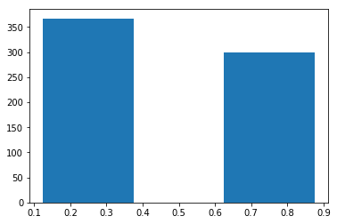

```python
df2 = pd.read_csv('./credit.data',sep='\t', header=None)
colonnes = df2.columns
values = df2.values

# Variables caracteristiques
X2 = values[:,:-1]
# Labels a predire
Y2 = values[:,-1]

X2[X2 == '?']=np.nan

# Converti en float
X2_num = X2[:,(1,2,7,10,13,14)]
X2_num = X2_num.astype(np.float32)

# Supprimer les nans
mask = np.any(np.isnan(X2_num), axis=1)
X2_num=X2_num[~mask]
Y2 = Y2[~mask]

# Converti
Y2[Y2 == '+'] = 1
Y2[Y2 == '-'] = 0

# Analyse des données
print(np.shape(Y2))
Y2 = Y2.astype(np.int)
plt.hist(Y2, bins=2,rwidth=0.5)
```

L'échantillon comporte désormais 666 individus après traitement, avec 367 crédits non accordés (0) et 299 accordés (1).

```python
# Evaluation des modeles sans la normalisation
def run_classifiers(clfs,X,Y):
    kf = KFold(n_splits=10, shuffle=True, random_state=1)
    for i in clfs:
        clf = clfs[i]
        print("\n\n======= {0} =======".format(i))
        start_time = time.time()
        cv_acc = cross_val_score(clf, X, Y, cv=kf)
        print('\nTemps d\'exécution d\'un cross val : %s secondes'%(time.time() - start_time))
        cv_auc = cross_val_score(clf, X, Y, cv=kf, scoring='roc_auc')
        cv_prec = cross_val_score(clf, X, Y, cv=kf, scoring='precision')
        print("Accuracy for {0} is: {1:.3f} +/- {2:.3f}".format(i, np.mean(cv_acc), np.std(cv_acc)))
        print("AUC for {0} is: {1:.3f} +/- {2:.3f}".format(i, cv_auc.mean(), cv_auc.std()))
        print("precision for {0} is: {1:.3f} +/- {2:.3f}".format(i, cv_prec.mean(), cv_prec.std()))


run_classifiers(clfs, X2_num, Y2)
```

```
======= MLP =======

Temps d'exécution d'un cross val : 4.2922303676605225 secondes
Accuracy for MLP is: 0.746 +/- 0.046
AUC for MLP is: 0.775 +/- 0.047
precision for MLP is: 0.729 +/- 0.050


======= ID3 =======

Temps d'exécution d'un cross val : 0.10726642608642578 secondes
Accuracy for ID3 is: 0.700 +/- 0.040
AUC for ID3 is: 0.699 +/- 0.041
precision for ID3 is: 0.662 +/- 0.057


======= ADABOOST =======

Temps d'exécution d'un cross val : 1.8083453178405762 secondes
Accuracy for ADABOOST is: 0.776 +/- 0.040
AUC for ADABOOST is: 0.838 +/- 0.055
precision for ADABOOST is: 0.776 +/- 0.082


======= BAGGING =======

Temps d'exécution d'un cross val : 2.425422191619873 secondes
Accuracy for BAGGING is: 0.778 +/- 0.038
AUC for BAGGING is: 0.831 +/- 0.044
precision for BAGGING is: 0.785 +/- 0.073


======= KPPV =======

Temps d'exécution d'un cross val : 0.04648280143737793 secondes
Accuracy for KPPV is: 0.700 +/- 0.060
AUC for KPPV is: 0.725 +/- 0.063
precision for KPPV is: 0.706 +/- 0.109


```

[output cut: 15 more lines]

```

======= NB =======

Temps d'exécution d'un cross val : 0.0376734733581543 secondes
Accuracy for NB is: 0.722 +/- 0.035
AUC for NB is: 0.793 +/- 0.065
precision for NB is: 0.834 +/- 0.123


======= KNN =======

Temps d'exécution d'un cross val : 0.04731559753417969 secondes
Accuracy for KNN is: 0.694 +/- 0.066
AUC for KNN is: 0.737 +/- 0.063
precision for KNN is: 0.736 +/- 0.120
```

L'évaluation globale d'un classifieur peut se faire à l'aide de l'aire sous la courbe ROC appelée AUC. Il semble que ce sont les méthodes ensemblistes qui donnent les meilleurs résultats si on ne normalise pas les données (Random forests, ADABOOST et bagging). On obtient jusqu'à une AUC de 0.845 avec avec les Random Forests.

```python
# On normalise maintenant les données
def run_classifiers_norm(clfs,X,Y):
    X = StandardScaler().fit(X).transform(X)
    kf = KFold(n_splits=10, shuffle=True, random_state=1)
    for i in clfs:
        clf = clfs[i]
        print("\n\n======= {0} =======".format(i))
        start_time = time.time()
        cv_acc = cross_val_score(clf, X, Y, cv=kf)
        print('\nTemps d\'exécution d\'un cross val : %s secondes'%(time.time() - start_time))
        cv_auc = cross_val_score(clf, X, Y, cv=kf, scoring='roc_auc')
        cv_prec = cross_val_score(clf, X, Y, cv=kf, scoring='precision')
        print("Accuracy for {0} is: {1:.3f} +/- {2:.3f}".format(i, np.mean(cv_acc), np.std(cv_acc)))
        print("AUC for {0} is: {1:.3f} +/- {2:.3f}".format(i, cv_auc.mean(), cv_auc.std()))
        print("precision for {0} is: {1:.3f} +/- {2:.3f}".format(i, cv_prec.mean(), cv_prec.std()))

run_classifiers_norm(clfs, X2_num, Y2)
```

```
======= MLP =======

Temps d'exécution d'un cross val : 4.317027807235718 secondes
Accuracy for MLP is: 0.733 +/- 0.044
AUC for MLP is: 0.780 +/- 0.040
precision for MLP is: 0.709 +/- 0.063


======= ID3 =======

Temps d'exécution d'un cross val : 0.1060800552368164 secondes
Accuracy for ID3 is: 0.698 +/- 0.040
AUC for ID3 is: 0.697 +/- 0.040
precision for ID3 is: 0.661 +/- 0.058


======= ADABOOST =======

Temps d'exécution d'un cross val : 1.8465638160705566 secondes
Accuracy for ADABOOST is: 0.776 +/- 0.040
AUC for ADABOOST is: 0.838 +/- 0.055
precision for ADABOOST is: 0.776 +/- 0.082


======= BAGGING =======

Temps d'exécution d'un cross val : 2.4674289226531982 secondes
Accuracy for BAGGING is: 0.778 +/- 0.038
AUC for BAGGING is: 0.831 +/- 0.045
precision for BAGGING is: 0.785 +/- 0.073


======= KPPV =======

Temps d'exécution d'un cross val : 0.06613397598266602 secondes
Accuracy for KPPV is: 0.755 +/- 0.045
AUC for KPPV is: 0.804 +/- 0.047
precision for KPPV is: 0.805 +/- 0.068


```

[output cut: 15 more lines]

```

======= NB =======

Temps d'exécution d'un cross val : 0.03782510757446289 secondes
Accuracy for NB is: 0.722 +/- 0.035
AUC for NB is: 0.793 +/- 0.065
precision for NB is: 0.834 +/- 0.123


======= KNN =======

Temps d'exécution d'un cross val : 0.0573885440826416 secondes
Accuracy for KNN is: 0.739 +/- 0.032
AUC for KNN is: 0.806 +/- 0.050
precision for KNN is: 0.841 +/- 0.057
```

Une normalisation standard n'améliore pas les méthodes ensemblistes qui se basent sur des arbres de classification (RF, bagging et adaboost). Cependant, cela améliore l'AUC des techniques utilisant les différentes variables en même temps dans l'agorithme comme les KPPV ou le MLP. L'AUC du KPPV passe alors de 0.725 à 0.804.

### Question 2 : Traitement sur les données manquantes

```python
from sklearn.preprocessing import Imputer

# Variables caracteristiques
X3 = values[:,:-1]
# Labels a predire
Y3 = values[:,-1]
Y3[Y3 == '+'] = 1
Y3[Y3 == '-'] = 0
Y3 = Y3.astype(float)

# Colonnes categorielles et numériques
col_cat = (0,3,4,5,6,8,9,11,12)
col_num = (1,2,7,10,13,14)
X_cat = np.copy(X3[:, col_cat])
X_cat = X_cat.astype(str)

# Variables categorielles
for col_id in range(len(col_cat)):
    unique_val, val_idx = np.unique(X_cat[:, col_id], return_inverse=True)
    X_cat[:, col_id] = val_idx
imp_cat = Imputer(missing_values=0, strategy='most_frequent')
X_cat[:, range(5)] = imp_cat.fit_transform(X_cat[:, range(5)])

# Variables numériques
X_num = np.copy(X3[:, col_num])
X_num[X_num == '?'] = np.nan
X_num = X_num.astype(float)
imp_num = Imputer(missing_values=np.nan, strategy='mean')
X_num = imp_num.fit_transform(X_num)
```

```python
from sklearn.preprocessing import OneHotEncoder

# On encode les variables categorielles
X_cat_bin = OneHotEncoder().fit_transform(X_cat).toarray()
X_num_norm = StandardScaler().fit(X_num).transform(X_num)

# Jeu de données final
X_proc = np.hstack((X_cat_bin, X_num_norm))
```

```python
# Classification
run_classifiers(clfs, X_proc, Y3)
```

```
======= MLP =======

Temps d'exécution d'un cross val : 9.610473155975342 secondes
Accuracy for MLP is: 0.818 +/- 0.053
AUC for MLP is: 0.853 +/- 0.045
precision for MLP is: 0.804 +/- 0.099


======= ID3 =======

Temps d'exécution d'un cross val : 0.15278959274291992 secondes
Accuracy for ID3 is: 0.804 +/- 0.039
AUC for ID3 is: 0.797 +/- 0.038
precision for ID3 is: 0.793 +/- 0.093


======= ADABOOST =======

Temps d'exécution d'un cross val : 2.116410493850708 secondes
Accuracy for ADABOOST is: 0.846 +/- 0.045
AUC for ADABOOST is: 0.910 +/- 0.051
precision for ADABOOST is: 0.814 +/- 0.063


======= BAGGING =======

Temps d'exécution d'un cross val : 3.3180441856384277 secondes
Accuracy for BAGGING is: 0.865 +/- 0.039
AUC for BAGGING is: 0.913 +/- 0.049
precision for BAGGING is: 0.842 +/- 0.081


======= KPPV =======

Temps d'exécution d'un cross val : 0.1545276641845703 secondes
Accuracy for KPPV is: 0.846 +/- 0.050
AUC for KPPV is: 0.906 +/- 0.043
precision for KPPV is: 0.846 +/- 0.098


======= RF =======

Temps d'exécution d'un cross val : 1.3382036685943604 secondes
Accuracy for RF is: 0.878 +/- 0.038
AUC for RF is: 0.928 +/- 0.047
precision for RF is: 0.850 +/- 0.070


======= CART =======

Temps d'exécution d'un cross val : 0.09280705451965332 secondes
Accuracy for CART is: 0.797 +/- 0.055
AUC for CART is: 0.790 +/- 0.064
precision for CART is: 0.764 +/- 0.076


======= NB =======

Temps d'exécution d'un cross val : 0.046060800552368164 secondes
Accuracy for NB is: 0.764 +/- 0.070
AUC for NB is: 0.868 +/- 0.056
precision for NB is: 0.868 +/- 0.081
```

L'apport de l'information des variables catégorielles augmente grandement la qualité de la classification. Si on regarde l'AUC ce sont toujours les classifieurs ensemblistes qui donnent les meilleurs résultats, avec le Random Forest en tête avec une AUC de 0.928 d'AUC. Le classifieur Bayésien reste cependant le classifieur qui donne la meilleurs précision de 0.868.

## III. Apprentissage supervisé sur des données textuelles : Feature engineering et Classification

```python
from sklearn.feature_extraction.text import CountVectorizer, TfidfTransformer

data3 = pd.read_csv('./SMSSpamCollection.data', sep='\t', header = None)
arraydata = data3.values

# Variables et labels
Xtxt = arraydata[:,1]
Ytxt = arraydata[:,0]

# Conversion du label
Ytxt[Ytxt == 'ham'] = 0
Ytxt[Ytxt == 'spam'] = 1
Ytxt = Ytxt.astype(int)

# On vectorise les sms
vectorizer = CountVectorizer()
Xvectorized = vectorizer.fit_transform(Xtxt)
run_classifiers(X=Xvectorized, Y=Ytxt, clfs=clfs)
```

```
======= MLP =======

Temps d'exécution d'un cross val : 21.15338945388794 secondes
Accuracy for MLP is: 0.987 +/- 0.002
AUC for MLP is: 0.984 +/- 0.010
precision for MLP is: 0.980 +/- 0.014


======= ID3 =======

Temps d'exécution d'un cross val : 4.25559663772583 secondes
Accuracy for ID3 is: 0.971 +/- 0.007
AUC for ID3 is: 0.922 +/- 0.025
precision for ID3 is: 0.919 +/- 0.025


======= ADABOOST =======

Temps d'exécution d'un cross val : 34.99478626251221 secondes
Accuracy for ADABOOST is: 0.973 +/- 0.002
AUC for ADABOOST is: 0.979 +/- 0.012
precision for ADABOOST is: 0.946 +/- 0.024


======= BAGGING =======

Temps d'exécution d'un cross val : 143.6916308403015 secondes
Accuracy for BAGGING is: 0.976 +/- 0.007
AUC for BAGGING is: 0.981 +/- 0.012
precision for BAGGING is: 0.940 +/- 0.027


======= KPPV =======

Temps d'exécution d'un cross val : 1.8782908916473389 secondes
Accuracy for KPPV is: 0.912 +/- 0.011
AUC for KPPV is: 0.855 +/- 0.023
precision for KPPV is: 1.000 +/- 0.000


======= RF =======

Temps d'exécution d'un cross val : 43.43914866447449 secondes
Accuracy for RF is: 0.978 +/- 0.006
AUC for RF is: 0.992 +/- 0.007
precision for RF is: 0.998 +/- 0.005


======= CART =======

Temps d'exécution d'un cross val : 5.238362073898315 secondes
Accuracy for CART is: 0.970 +/- 0.009
AUC for CART is: 0.926 +/- 0.029
precision for CART is: 0.908 +/- 0.028


======= NB =======
```

[output not shown]

[output cut: 58 more lines]

[output not shown]

On constate que juste en vectorisant les sms, les résulats de classification sont très bon. Les techniques ensemblistes restent les meilleurs, principalement avec le modèle de Random Forest qui donne une AUC de 0.992 et une précision de 0.998. On remarque aussi que le classifieur Bayésien ne fonctionne pas avec les sparses matrix.

```python
# On fait une validation croisée a k = 5 pour augmenter la rapidité
def run_classifiers(clfs,X,Y):
    kf = KFold(n_splits=5, shuffle=True, random_state=1)
    for i in clfs:
        clf = clfs[i]
        print("\n\n======= {0} =======".format(i))
        start_time = time.time()
        cv_acc = cross_val_score(clf, X, Y, cv=kf)
        print('\nTemps d\'exécution d\'un cross val : %s secondes'%(time.time() - start_time))
        cv_auc = cross_val_score(clf, X, Y, cv=kf, scoring='roc_auc')
        cv_prec = cross_val_score(clf, X, Y, cv=kf, scoring='precision')
        print("Accuracy for {0} is: {1:.3f} +/- {2:.3f}".format(i, np.mean(cv_acc), np.std(cv_acc)))
        print("AUC for {0} is: {1:.3f} +/- {2:.3f}".format(i, cv_auc.mean(), cv_auc.std()))
        print("precision for {0} is: {1:.3f} +/- {2:.3f}".format(i, cv_prec.mean(), cv_prec.std()))


Xtfidf = TfidfTransformer(smooth_idf=False).fit_transform(Xvectorized)
run_classifiers(X=Xtfidf, Y=Ytxt, clfs=clfs)
```

```
======= MLP =======

Temps d'exécution d'un cross val : 11.159014463424683 secondes
Accuracy for MLP is: 0.984 +/- 0.004
AUC for MLP is: 0.989 +/- 0.005
precision for MLP is: 0.972 +/- 0.018


======= ID3 =======

Temps d'exécution d'un cross val : 4.998236179351807 secondes
Accuracy for ID3 is: 0.968 +/- 0.003
AUC for ID3 is: 0.918 +/- 0.012
precision for ID3 is: 0.901 +/- 0.005


======= ADABOOST =======

Temps d'exécution d'un cross val : 24.2587628364563 secondes
Accuracy for ADABOOST is: 0.972 +/- 0.002
AUC for ADABOOST is: 0.972 +/- 0.008
precision for ADABOOST is: 0.930 +/- 0.012


======= BAGGING =======

Temps d'exécution d'un cross val : 89.84316778182983 secondes
Accuracy for BAGGING is: 0.975 +/- 0.003
AUC for BAGGING is: 0.982 +/- 0.009
precision for BAGGING is: 0.945 +/- 0.012


======= KPPV =======

Temps d'exécution d'un cross val : 1.5532004833221436 secondes
Accuracy for KPPV is: 0.932 +/- 0.032
AUC for KPPV is: 0.968 +/- 0.012
precision for KPPV is: 0.996 +/- 0.005


======= RF =======

Temps d'exécution d'un cross val : 18.36499047279358 secondes
Accuracy for RF is: 0.975 +/- 0.004
AUC for RF is: 0.992 +/- 0.004
precision for RF is: 0.998 +/- 0.003


======= CART =======

Temps d'exécution d'un cross val : 3.7133629322052 secondes
Accuracy for CART is: 0.968 +/- 0.003
AUC for CART is: 0.925 +/- 0.009
precision for CART is: 0.892 +/- 0.017


======= NB =======
```

[output not shown]

[output cut: 58 more lines]

[output not shown]

```python
from sklearn.decomposition import TruncatedSVD

svd = TruncatedSVD(n_components=100, n_iter=7, random_state=1)
Xtrunc = svd.fit_transform(Xtfidf)

run_classifiers(X=Xtrunc, Y=Ytxt, clfs=clfs)
```

```
======= MLP =======

Temps d'exécution d'un cross val : 16.58793544769287 secondes
Accuracy for MLP is: 0.973 +/- 0.003
AUC for MLP is: 0.987 +/- 0.005
precision for MLP is: 0.890 +/- 0.018


======= ID3 =======

Temps d'exécution d'un cross val : 6.809550523757935 secondes
Accuracy for ID3 is: 0.953 +/- 0.001
AUC for ID3 is: 0.909 +/- 0.009
precision for ID3 is: 0.812 +/- 0.025


======= ADABOOST =======

Temps d'exécution d'un cross val : 32.357205390930176 secondes
Accuracy for ADABOOST is: 0.972 +/- 0.006
AUC for ADABOOST is: 0.981 +/- 0.003
precision for ADABOOST is: 0.920 +/- 0.032


======= BAGGING =======

Temps d'exécution d'un cross val : 168.47836565971375 secondes
Accuracy for BAGGING is: 0.973 +/- 0.005
AUC for BAGGING is: 0.973 +/- 0.006
precision for BAGGING is: 0.960 +/- 0.010


======= KPPV =======

Temps d'exécution d'un cross val : 13.758306741714478 secondes
Accuracy for KPPV is: 0.968 +/- 0.007
AUC for KPPV is: 0.966 +/- 0.013
precision for KPPV is: 0.963 +/- 0.030


======= RF =======

Temps d'exécution d'un cross val : 16.525413751602173 secondes
Accuracy for RF is: 0.974 +/- 0.004
AUC for RF is: 0.975 +/- 0.009
precision for RF is: 0.986 +/- 0.009


======= CART =======

Temps d'exécution d'un cross val : 5.491069078445435 secondes
Accuracy for CART is: 0.950 +/- 0.004
AUC for CART is: 0.906 +/- 0.012
precision for CART is: 0.798 +/- 0.036


======= NB =======

Temps d'exécution d'un cross val : 0.06766796112060547 secondes
Accuracy for NB is: 0.826 +/- 0.008
AUC for NB is: 0.928 +/- 0.011
precision for NB is: 0.427 +/- 0.021
```

On constate que passer des sparses matrix à un array réduit par indexation sémantique diminue la qualité de la classification. Par exemple, l'AUC de la random forest passe de 0.992 à 0.975. Cela doit venir du parametre n_components qui indique le nombre de dimensions à utiliser. On va essayer d'augmenter ce paramètre sur les randoms forests et un classifieur Bayésien.

```python
clfs2 = {
'NB': GaussianNB(),
'RF': RandomForestClassifier(n_estimators=50, random_state=1)
}

svd = TruncatedSVD(n_components=200, n_iter=7, random_state=1)
Xtrunc = svd.fit_transform(Xtfidf)

run_classifiers(X=Xtrunc, Y=Ytxt, clfs=clfs2)
```

```
======= NB =======

Temps d'exécution d'un cross val : 0.168809175491333 secondes
Accuracy for NB is: 0.871 +/- 0.005
AUC for NB is: 0.949 +/- 0.008
precision for NB is: 0.510 +/- 0.024


======= RF =======

Temps d'exécution d'un cross val : 25.9538311958313 secondes
Accuracy for RF is: 0.970 +/- 0.003
AUC for RF is: 0.974 +/- 0.011
precision for RF is: 0.992 +/- 0.007
```

Augmenter le nombre de dimensions à 200 ne change pas beaucoup l'AUC du random forest (0.975 à 0.974) mais augmente la précision 0.986 de 0.992. Cependant, les résultats de la classification restent plus bas que juste avec la vectorisation des chaines de caractères. La réduction des dimensions du jeu de données fait sans doute perdre de l'information ce qui baisse la qualité de la prédiction.

```python
# Pipeline de traitement de texte pour la classification
pipeline = Pipeline([
    ('Vectorize', CountVectorizer()),
    ('Weights', TfidfTransformer(smooth_idf=False)),
    ('Truncation', TruncatedSVD(n_components=4, n_iter=7, random_state=1))])

# Nouveau jeu de données
DF = pd.read_csv('./yelp-text-by-stars.csv', sep=';', engine='python')
arraydata2 = DF.values

# Variables et labels
Xyelp = arraydata2[:,1]
Yyelp = arraydata2[:,0]
Yyelp = Yyelp.astype(int)

# Traitement des données de texte
Xprocessed = pipeline.fit_transform(Xyelp)
```

```python
# On calcule seulement l'accuracy ici etant donné que c'est du multilabel (+reduit le temps de calcul)
def run_classifiers_acc(clfs,X,Y):
    X = StandardScaler().fit(X).transform(X)
    kf = KFold(n_splits=3, shuffle=True, random_state=1)
    for i in clfs:
        clf = clfs[i]
        print("\n\n======= {0} =======".format(i))
        start_time = time.time()
        cv_acc = cross_val_score(clf, X, Y, cv=kf)
        print('\nTemps d\'exécution d\'un cross val : %s secondes'%(time.time() - start_time))
        print("Accuracy for {0} is: {1:.3f} +/- {2:.3f}".format(i, np.mean(cv_acc), np.std(cv_acc)))

run_classifiers_acc(X=Xprocessed, Y=Yyelp, clfs=clfs)
```

```
======= MLP =======

Temps d'exécution d'un cross val : 69.59812831878662 secondes
Accuracy for MLP is: 0.489 +/- 0.003


======= ID3 =======

Temps d'exécution d'un cross val : 6.492163896560669 secondes
Accuracy for ID3 is: 0.372 +/- 0.004


======= ADABOOST =======

Temps d'exécution d'un cross val : 13.109768152236938 secondes
Accuracy for ADABOOST is: 0.481 +/- 0.003


======= BAGGING =======

Temps d'exécution d'un cross val : 75.81055498123169 secondes
Accuracy for BAGGING is: 0.449 +/- 0.004


======= KPPV =======

Temps d'exécution d'un cross val : 1.444054126739502 secondes
Accuracy for KPPV is: 0.433 +/- 0.001


======= RF =======

Temps d'exécution d'un cross val : 36.187769412994385 secondes
Accuracy for RF is: 0.454 +/- 0.003


======= CART =======

Temps d'exécution d'un cross val : 2.0903873443603516 secondes
Accuracy for CART is: 0.372 +/- 0.002


======= NB =======

Temps d'exécution d'un cross val : 0.1092081069946289 secondes
Accuracy for NB is: 0.473 +/- 0.003
```

On constate que l'accuracy des différents modèle est relativement basse, avec un maximum de 0.489 pour le MLP. Les mathodes ensemblistes marchent presque aussi bien tout comme le Naive Bayesian classifieur (0.473). Ces scores bien plus bas que les précédents proviennent tout d'abord d'un nombre de dimensions choisi bas lors de la réduction des dimensions (4). Avec plus de temps, il faudrait essayer une valeur plus grand de ce paramètre. Cela prend du temps de tester plusieurs combinaisons avec plusieurs modèles, le jeu de données étant très grand. De plus, contrairement aux précédents, ce jeu est multilabels avec 5 valeurs possibles, ce qui complique grandement la tache de classification comme on peut le voir sur les résultats.